# May institute Data visualization module: Hands-on 2

Ting Huang

May 8, 2017

# Objectives

- Data Exploration
- Plot types
  - Bar plot and pie chart
  - Histogram
  - Scatter plot
  - Text plot
  - Boxplot and violin plot
  - Line chart
  - Heatmap

# 1. Data Exploration

In this section we’ll continue using the colonrectal cancer dataset. But besides sub group information, we’ll explore other sample information.

```r
CRC <- read.csv("./data/CRC_train.csv")
str(CRC[,73:79])
```

```
## 'data.frame':    200 obs. of  7 variables:
##  $ Sample         : Factor w/ 200 levels "P1A1","P1A10",..: 2 4 5 7 11 12 13 16 18 21 ...
##  $ Group          : Factor w/ 2 levels "CRC","Healthy": 1 1 1 1 1 1 1 1 1 1 ...
##  $ Age            : int  60 70 65 65 62 55 61 52 89 81 ...
##  $ Gender         : Factor w/ 2 levels "female","male": 1 2 2 1 1 2 2 2 1 2 ...
##  $ Cancer_stage   : int  1 1 1 4 3 2 2 4 4 1 ...
##  $ Tumour_location: Factor w/ 2 levels "colon","rectum": 1 2 2 1 1 1 2 2 1 2 ...
##  $ Sub_group      : Factor w/ 3 levels "Benign","CRC",..: 2 2 2 2 2 2 2 2 2 2 ...
```

```r
# Inspect the possible values for the annotation columns
unique(CRC[, 'Cancer_stage'])
```

```
## [1]  1  4  3  2 NA
```

```r
unique(CRC[, 'Tumour_location'])
```

```
## [1] colon  rectum <NA>
## Levels: colon rectum
```

```r
unique(CRC[, 'Sub_group'])
```

```
## [1] CRC     Benign  Healthy
## Levels: Benign CRC Healthy
```

# 2. Plot types

## 2.1 Bar plot and pie chart

`geom_bar()` makes the height of the bar proportional to the number of cases in each group.

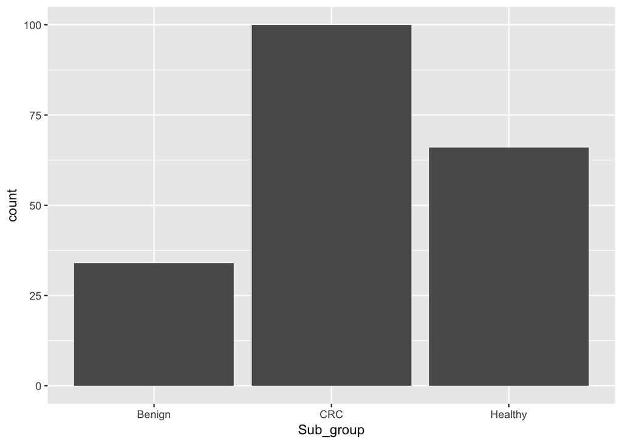

```r
library(ggplot2)
# Investigate the number of each sub_group
g1 <- ggplot(CRC, aes(Sub_group))
g1 + geom_bar()
```

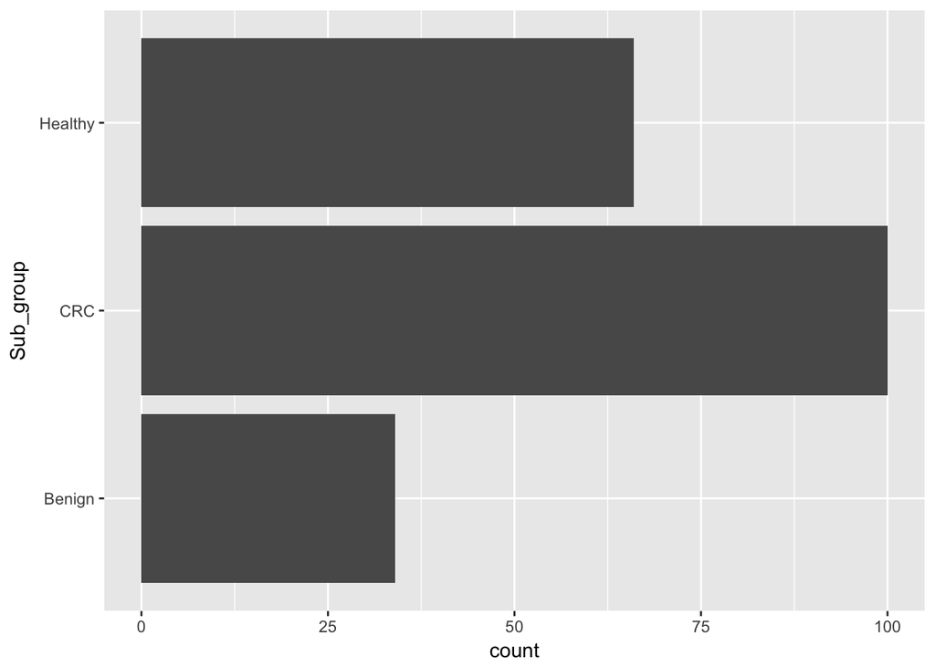

```r
# horizontal barplot
g1 + geom_bar() +
  coord_flip()
```

We can also calculate the number of patients in each group manually and then make bar plot with `stat="identity"`

```r
library(dplyr)
# count the number of samples in each sub group
n_subgroup <- CRC %>% group_by(Sub_group) %>% summarise(N = n())
n_subgroup
```

```
## # A tibble: 3 × 2
##   Sub_group     N
##      <fctr> <int>
## 1    Benign    34
## 2       CRC   100
## 3   Healthy    66
```

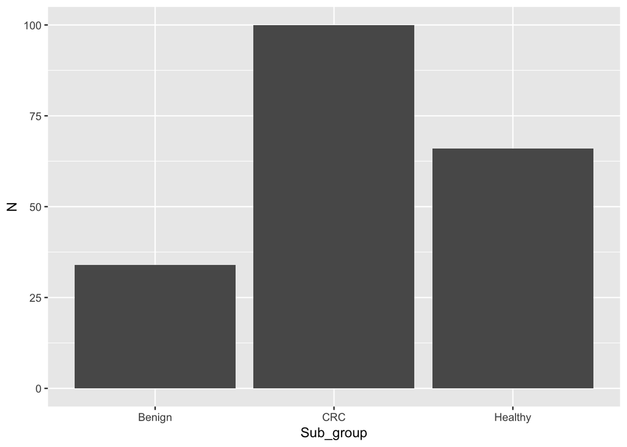

```r
ggplot(n_subgroup, aes(x=Sub_group, y=N)) +
  geom_bar(stat="identity")
```

We want to know the count of different gender patients in each sub group

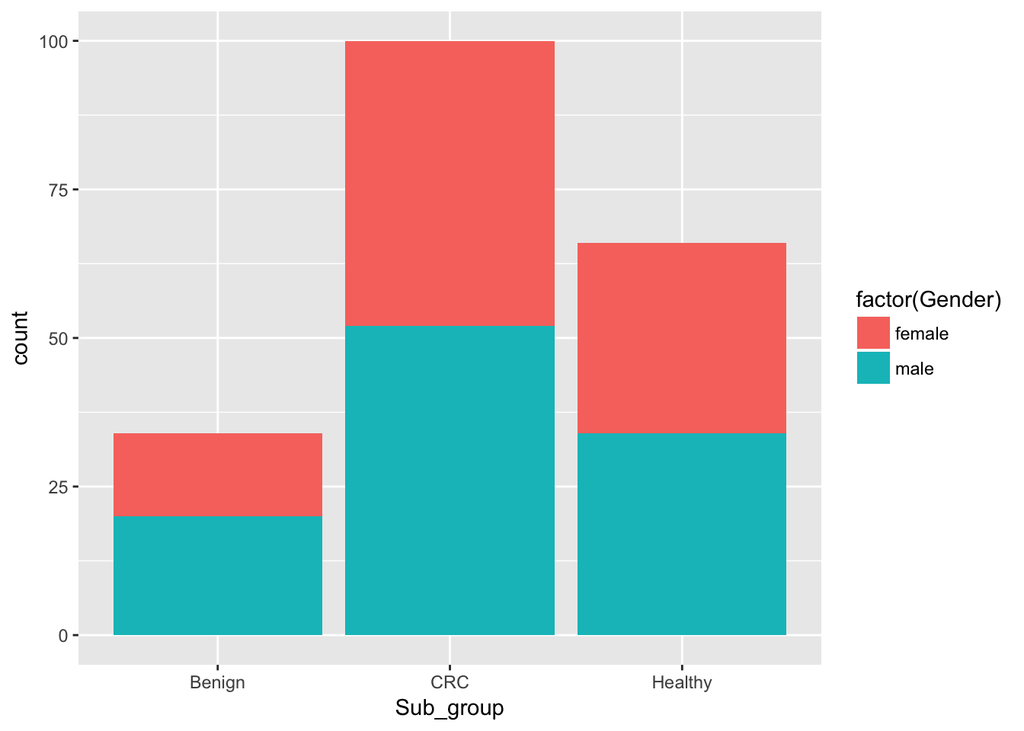

```r
g2 <- ggplot(CRC, aes(Sub_group, fill=factor(Gender)))
# Stacked barplot puts overlapping bars on top of each other
g2 + geom_bar(position = "stack")
```

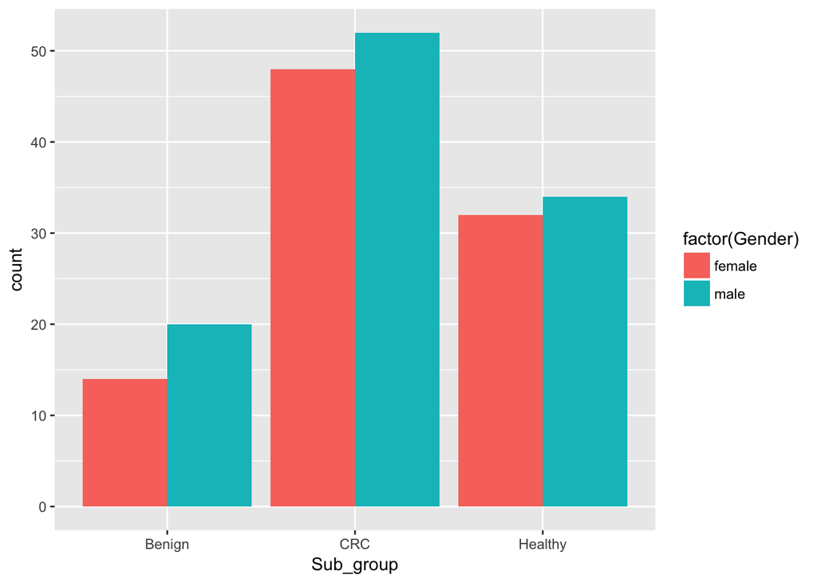

```r
# place overlapping bars side-by-side
g2 + geom_bar(position = "dodge")
```

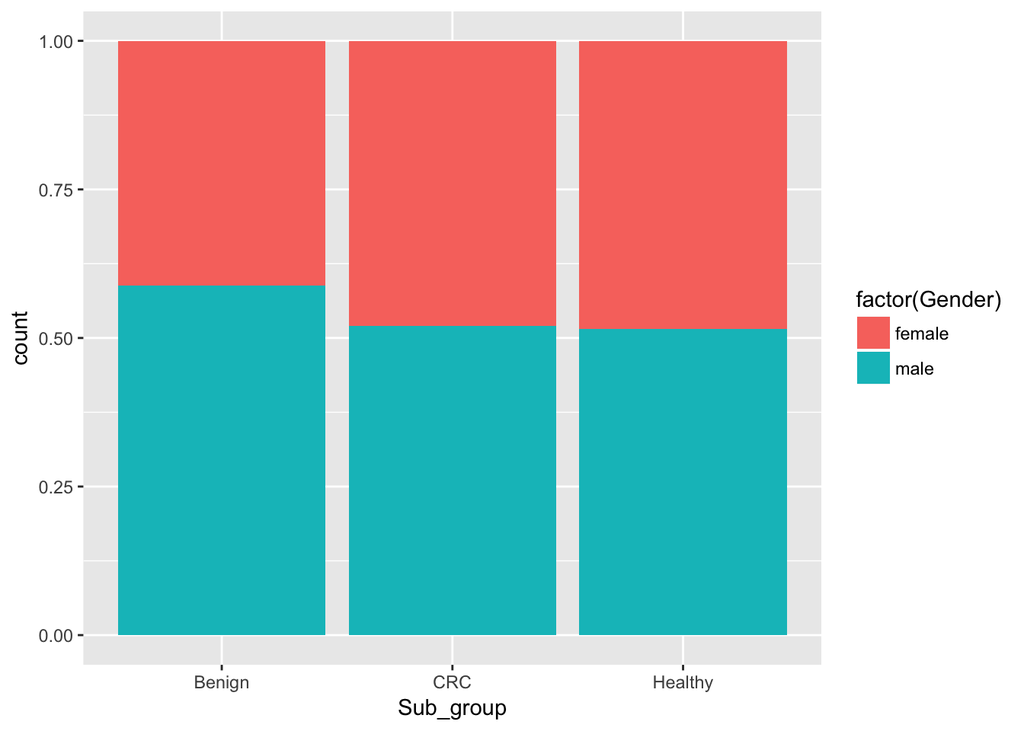

```r
#displays proportions
g2 + geom_bar(position = "fill")
```

Pie chart is changed from bar chart through `coord_polar()`

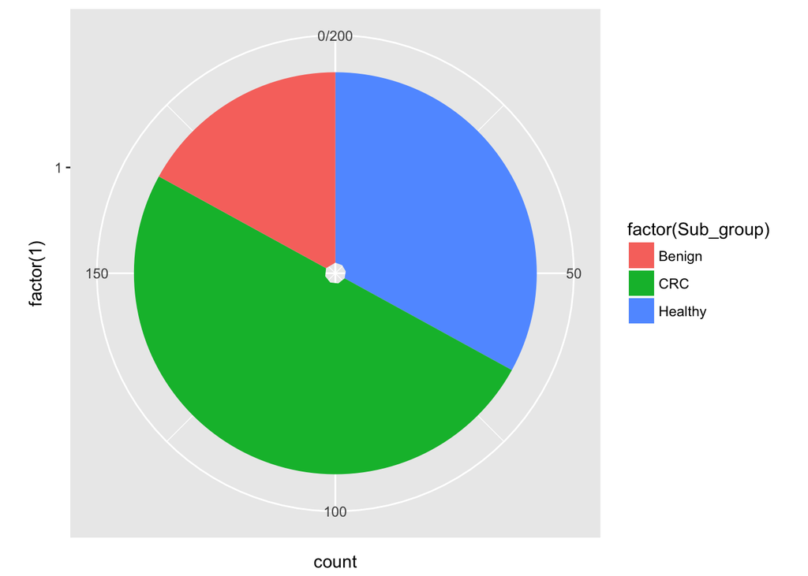

```r
ggplot(data = CRC) +
  geom_bar(mapping = aes(x = factor(1), fill = factor(Sub_group))) +
  coord_polar(theta = "y")
```

## 2.2 Histogram

We want to Investigate the abundance distribution of one protein. `geom_histogram()` shows the distribution of a single variable

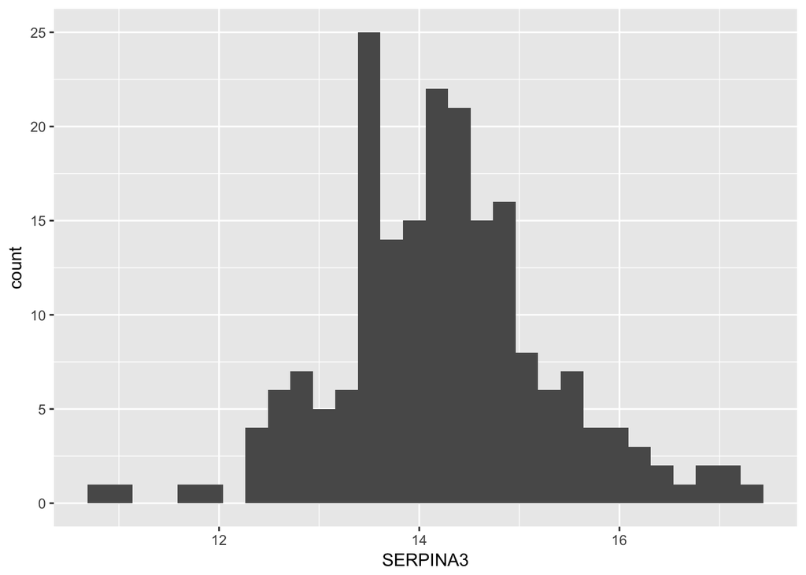

```r
g3 <- ggplot(CRC, aes(SERPINA3))
g3 + geom_histogram()
```

`freqency polygons` show the distribution of a single variable with lines

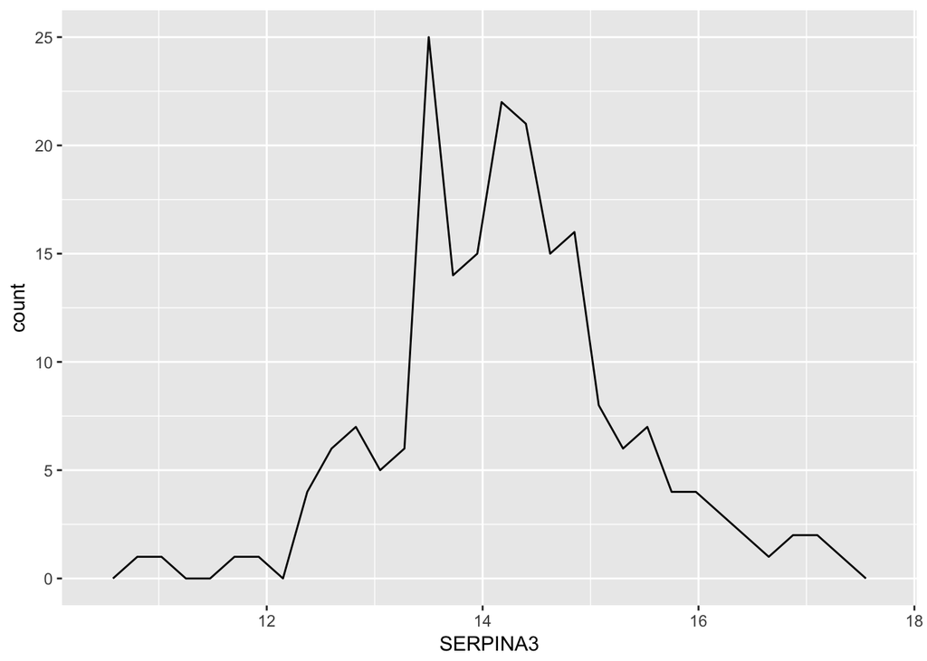

```r
g3 + geom_freqpoly()
```

> **Challenge** If you want to know the density distribution of protein ??AFM?? among all the observations, what plot will you make?

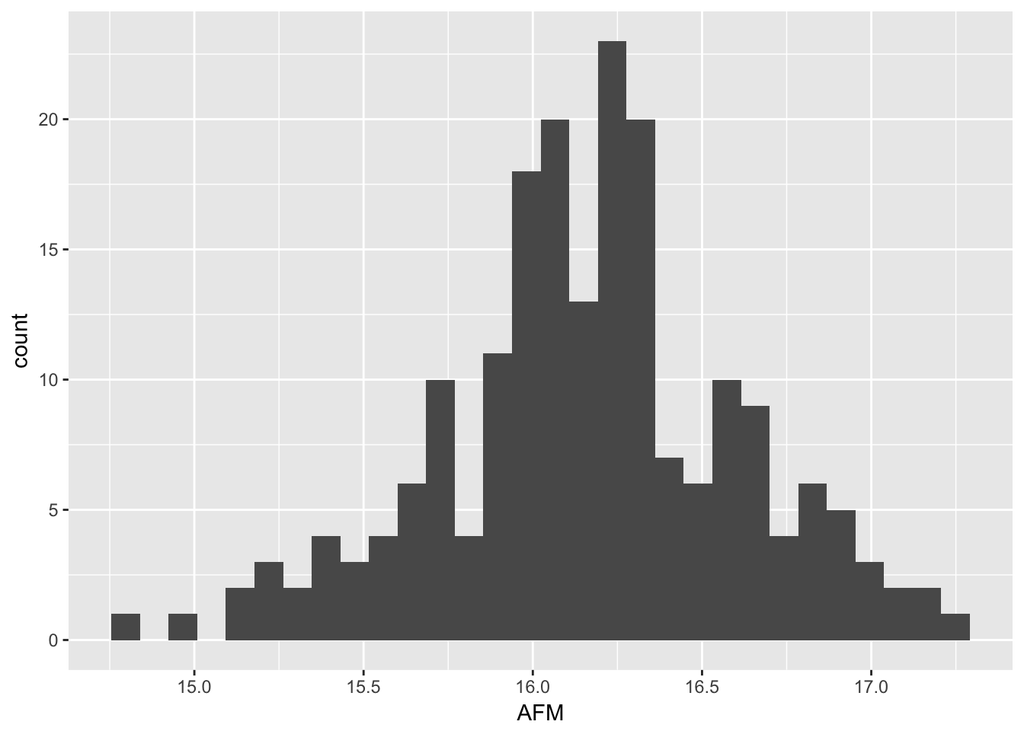

```r
g <- ggplot(CRC, aes(AFM))
g + geom_histogram()
```

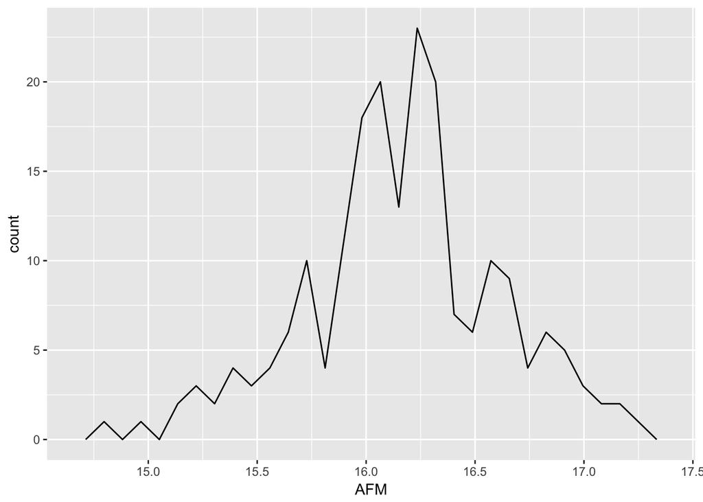

```r
g + geom_freqpoly()
```

## 2.3 Scatter plot

We want to investigate the relation between two proteins. `geom_point()` is used to create scatterplots. The scatterplot is most useful for displaying the relationship between two continuous variables.

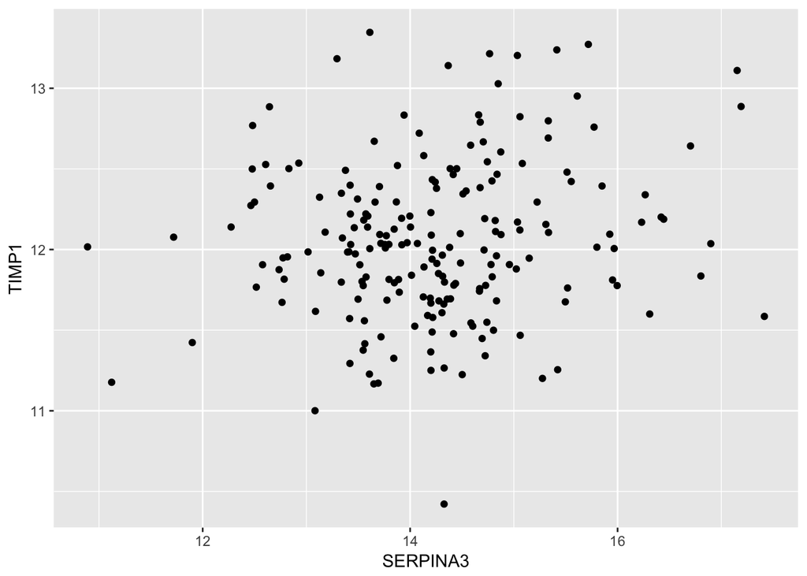

```r
g <- ggplot(CRC, aes(x = SERPINA3, y = TIMP1))
g + geom_point()
```

If you have a scatterplot with a lot of noise, it can be hard to see the dominant pattern. In this case it’s useful to add a smoothed line to the plot with `geom_smooth()`

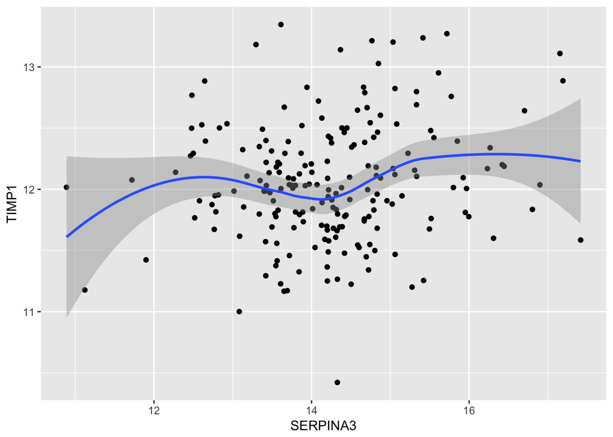

```r
g + geom_point() +
  geom_smooth()
```

`smoothScatter()` produces a smoothed color density representation of a scatterplot

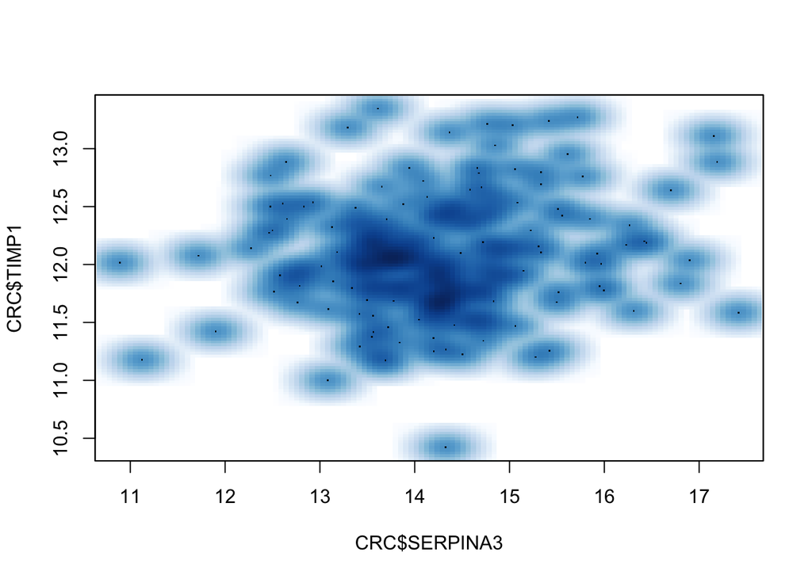

```r
smoothScatter(CRC$SERPINA3, CRC$TIMP1)
```

> **Challenge** If you want to the relationship of abundance between protein ??AFM?? and ??AHSG??, what plot will you make?

## 2.4 Text plot

`geom_text` can add text to the plot

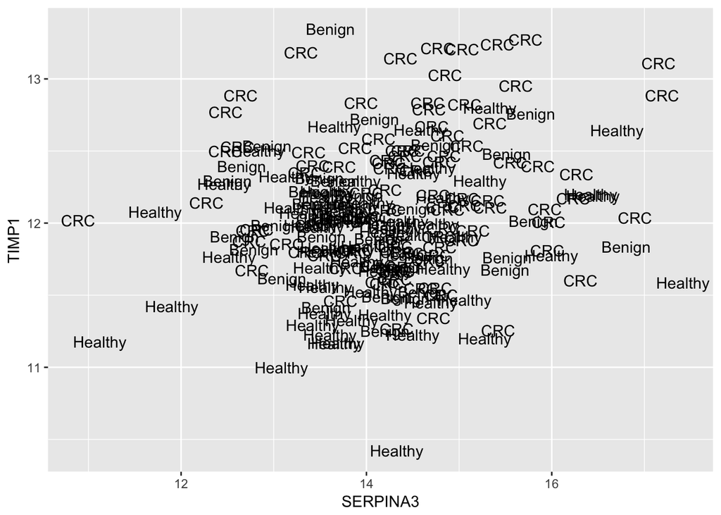

```r
g + geom_text(aes(label = Sub_group))
```

`check_overlap` can remove the overlapped texts

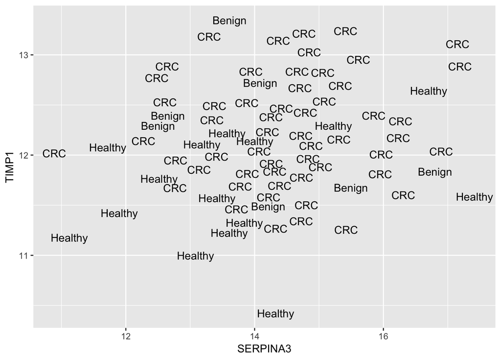

```r
g + geom_text(aes(label = Sub_group), check_overlap = TRUE)
```

We can aslo add points to the plot.

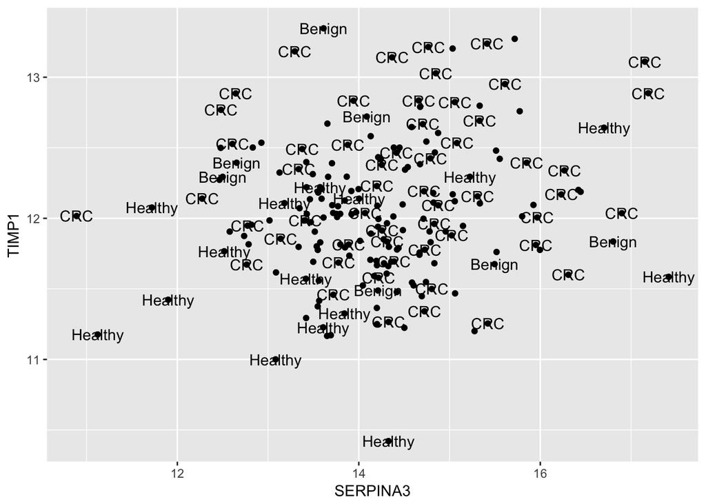

```r
g + geom_text(aes(label = Sub_group), check_overlap = TRUE) +
  geom_point()
```

`nudge_x` and `nudge_y` can offset the text

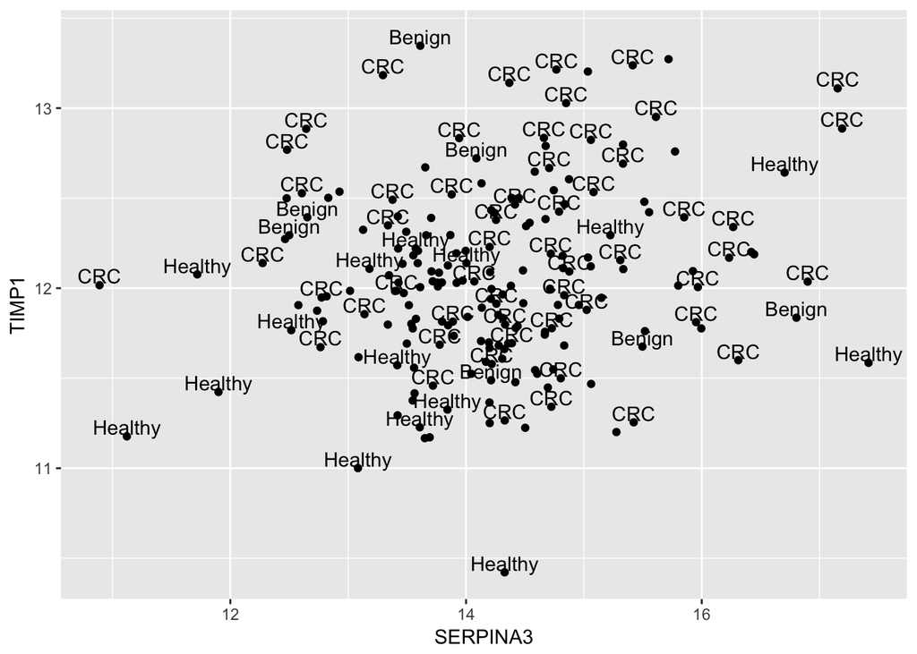

```r
g + geom_text(aes(label = Sub_group), nudge_y = 0.05, check_overlap = TRUE) +
  geom_point()
```

Adding labels to bar plot

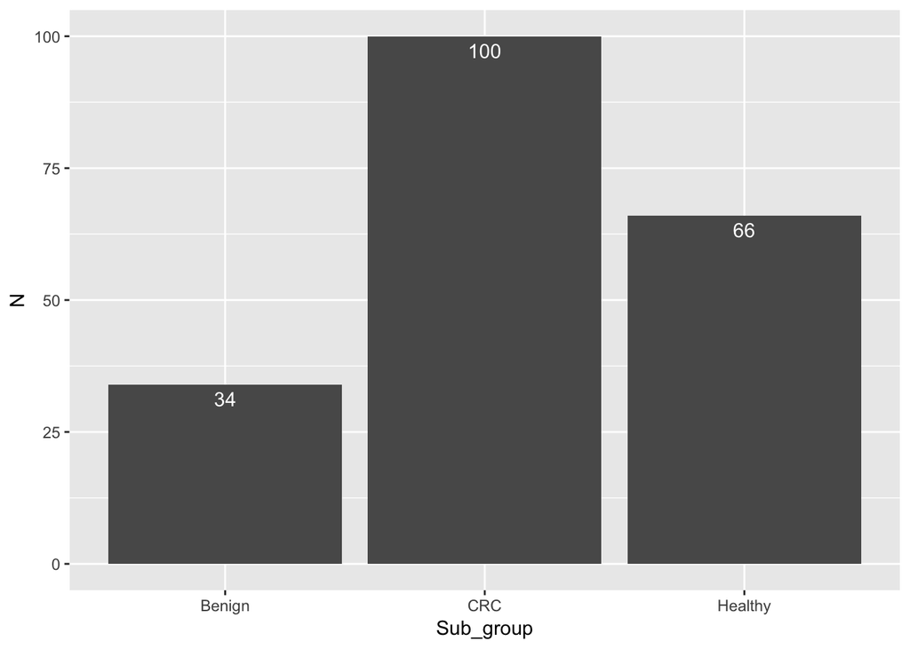

```r
# create a ggplot data
ggplot(n_subgroup, aes(x=Sub_group, y=N)) +
  # draw the bar plot
  geom_bar(stat="identity") +
  # create the number text above the bar in white
  geom_text(aes(label=N), vjust=1.5, colour="white")
```

## 2.5 Boxplot and violin plot

We want to investigate how protein abundance varies across different groups. `geom_boxplot()` summarise the shape of the distribution with a handful of summary statistics.

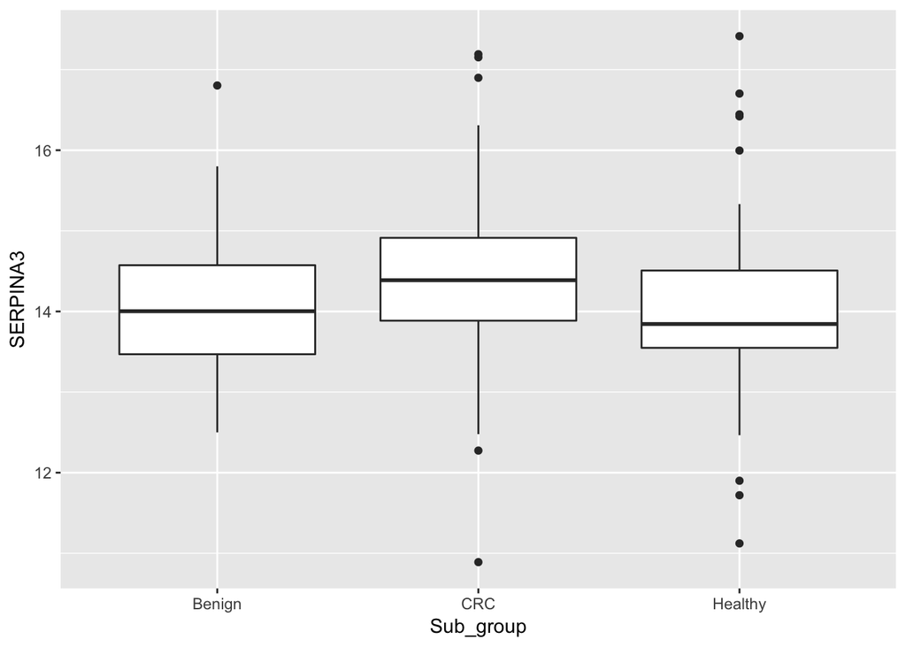

```r
b <- ggplot(CRC, aes(Sub_group, SERPINA3))
b + geom_boxplot()
```

We want to consider another factor *gender*

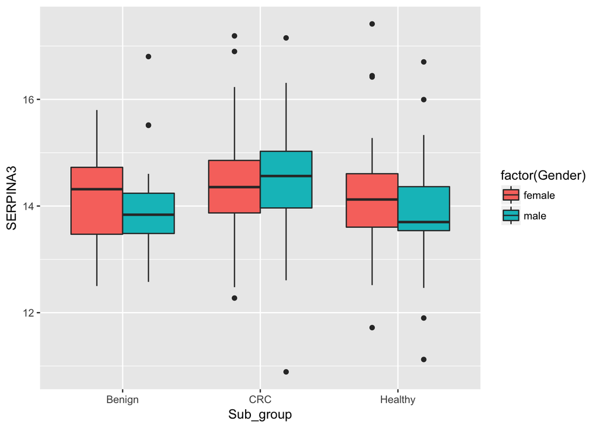

```r
b + geom_boxplot(aes(fill= factor(Gender)), position = "dodge")
```

A violin plot is a mirrored density plot displayed in the same way as a boxplot.

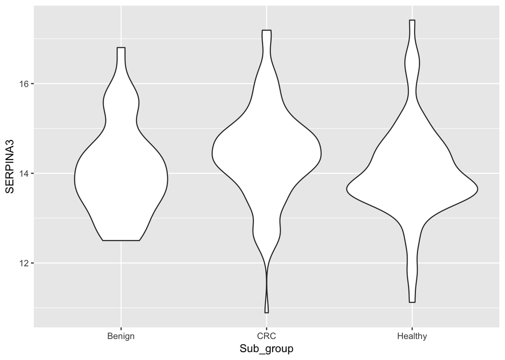

```r
b + geom_violin()
```

### 3.5 Line chart

We want to know how the protein abundance changes across different samples.

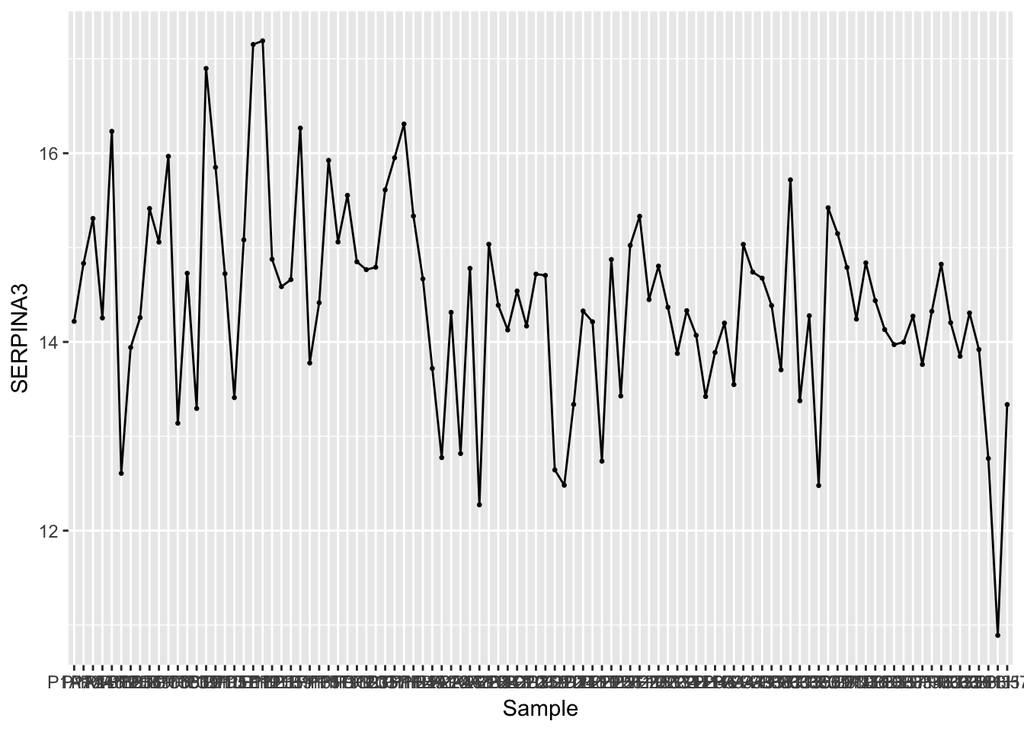

```r
ggplot(CRC[1:100,],aes(Sample, SERPINA3, group = 1)) +
  geom_point(size = 0.5) +
  geom_line()
```

> **Challenge** If you want to compare the abundance distribution of protein ??AFM?? among different groups, what plot will make? And you also want to see the difference between male and female in each group, what change will make?

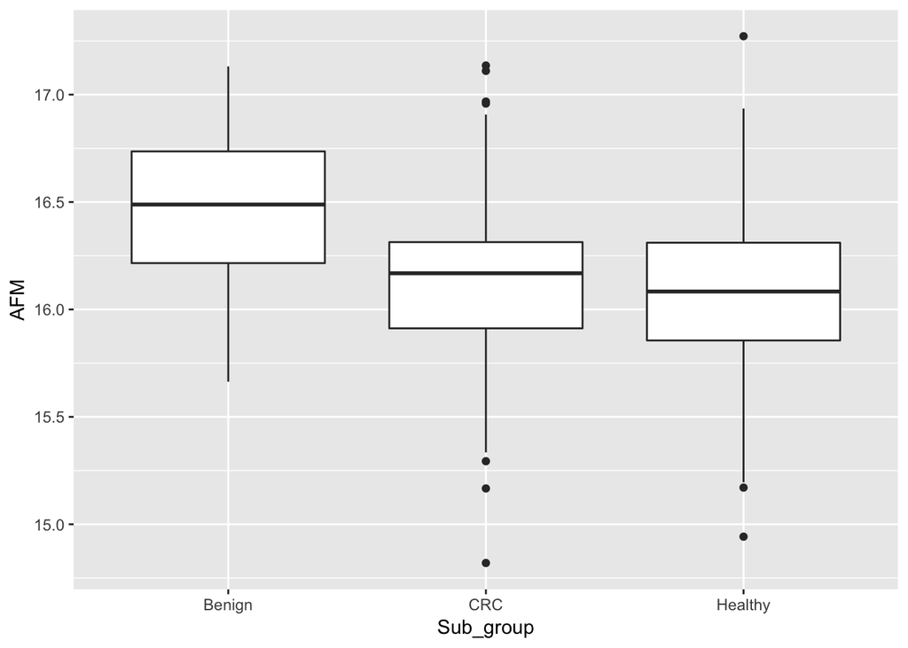

```r
ggplot(CRC) +
  geom_boxplot(aes(Sub_group, AFM))
```

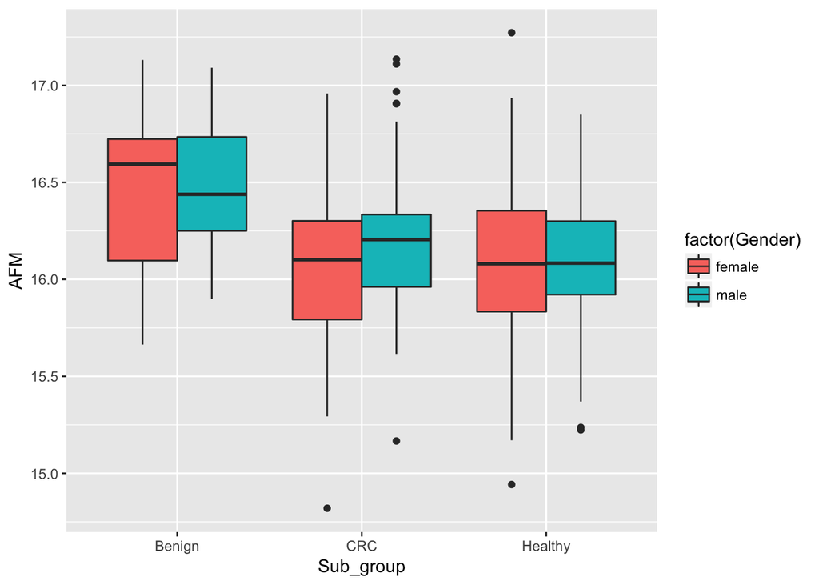

```r
ggplot(CRC) +
  geom_boxplot(aes(Sub_group, AFM, fill= factor(Gender)), position = "dodge")
```